# Quantitative Reasoning Indirect Assessment Report

# 1 Study

## 1.1 Background

A survey, Indirect Assessment in Quantitative Reasoning, was used to complement the [Quantitative Reasoning Rubric](https://drive.google.com/file/d/1eij-N3jRgmW2dth-U7Mz3qb-zrdcTRJk/view) for direct assessment.

## 1.2 Method and Sample

The survey was distributed through Google Forms to assess quantitative reasoning skills and engagement using the “Standard Form.”

The data was collected during the last two weeks of the Spring 2024 semester, resulting in 469 complete student responses.

## 1.3 Variables

Variable names, full wording of the questions, short labels used in analyses, and the response sets are as follows.

[output not shown]

# 2 Results

## 2.1 Quantitative Reasoning Skills: Summary

### 2.1.1 Table 1. Frequencies of Core Quantitative Reasoning Skills

| Core QR Skills - Items | N = 4691 |
| --- | --- |
| [Methodology] Described the methods used to solve a quantitative problem and why they were appropriate |  |
| Never | 19 (4.1%) |
| Infrequently | 57 (12%) |
| Sometimes | 202 (43%) |
| Frequently | 188 (40%) |
| [Calculation] Carried out calculations, either by hand or using software |  |
| Never | 9 (1.9%) |
| Infrequently | 30 (6.4%) |
| Sometimes | 125 (27%) |
| Frequently | 304 (65%) |
| [Visual Representation] Created a visual representation of numerical information (graph, table, chart, etc.) |  |
| Never | 14 (3.0%) |
| Infrequently | 33 (7.0%) |
| Sometimes | 157 (33%) |
| Frequently | 265 (57%) |
| [Interpretation] Described numerical information (numbers, graphs, statistics, etc.) by writing in words |  |
| Never | 12 (2.6%) |
| Infrequently | 51 (11%) |
| Sometimes | 151 (32%) |
| Frequently | 252 (54%) |
| [Evaluation] Reached conclusions based on your own analysis of numerical information (numbers, graphs, statistics, etc.) |  |
| Never | 10 (2.1%) |
| Infrequently | 42 (9.0%) |
| Sometimes | 175 (38%) |
| Frequently | 239 (51%) |
| [Coherence/Purpose] Constructed a single, coherent argument using several conclusions that were each based on quantitative evidence |  |
| Never | 27 (5.8%) |
| Infrequently | 89 (19%) |
| Sometimes | 190 (41%) |
| Frequently | 159 (34%) |
| [Reasonableness] Decided when a solution or inference was reasonable or not reasonable in the context of a problem |  |
| Never | 17 (3.6%) |
| Infrequently | 53 (11%) |
| Sometimes | 219 (47%) |
| Frequently | 179 (38%) |

1n (%)

**Table 1** presents the frequencies of student engagement in various quantitative activities within the class, measured through seven different questions.

“Carried out calculations, either by hand or using software,” shows that a significant majority of students, 65%, frequently engage in calculations. “Created a visual representation, like a graph, chart, or diagram,” indicates that 56.5% of students frequently create visual representations. “Interpreted numerical information by writing in words,” shows 54.1% of students frequently interpret numerical data in written form.

The last three items received the least “frequently” responses display more advanced quantitative reasoning and analysis.”Described the methods used to solve a quantitative problem and why they were appropriate” shows 40.3% of students frequently describe methodology. “Decided when a solution or inference was reasonable or not reasonable in the context of a problem” indicates that 38.2% of students frequently assess reasonableness. Finally, the item “Constructed a single, coherent argument using several conclusions that were each based on quantitative evidence” has the lowest “frequently” response at 34.2%, which is less common among students.

### 2.1.2 Figure 1. Frequencies of Core Quantitative Reasoning Skills

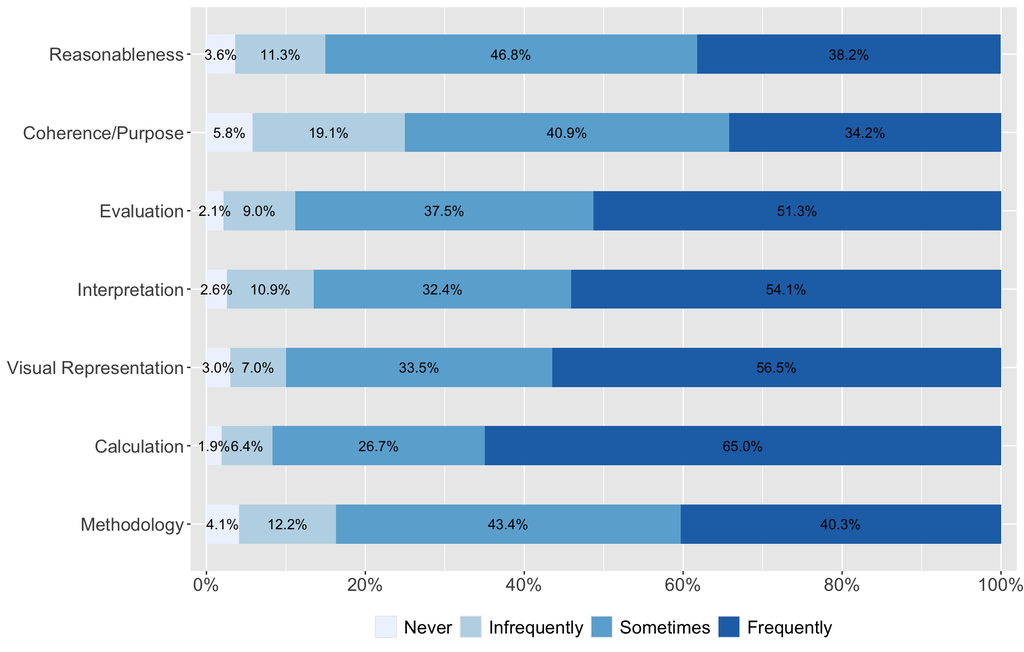

Note: Alternative of the above table.

### 2.1.3 Table 2. Descriptive Statistics of Core Quantitative Reasoning Skills

| Core QR Skills - Items | N = 4691 |
| --- | --- |
| [Calculation] Carried out calculations, either by hand or using software | 3.55 (0.70) |
| [Visual Representation] Created a visual representation of numerical information (graph, table, chart, etc.) | 3.43 (0.75) |
| [Interpretation] Described numerical information (numbers, graphs, statistics, etc.) by writing in words | 3.38 (0.78) |
| [Evaluation] Reached conclusions based on your own analysis of numerical information (numbers, graphs, statistics, etc.) | 3.38 (0.74) |
| [Methodology] Described the methods used to solve a quantitative problem and why they were appropriate | 3.20 (0.81) |
| [Reasonableness] Decided when a solution or inference was reasonable or not reasonable in the context of a problem | 3.20 (0.78) |
| [Coherence/Purpose] Constructed a single, coherent argument using several conclusions that were each based on quantitative evidence | 3.03 (0.88) |

1Mean (SD)

**Table 2** presents the descriptive statistics of core quantitative reasoning skills. The highest mean score is for “Calculation” at 3.55 out of four. “Visual representation” has a mean score of 3.43. “Interpretation” and “Evaluation” both have a mean score of 3.38. Students describe numerical information in written form and reach conclusions based on analysis at similar frequencies.

“Reasonableness” and “Methodology” both score 3.20. Students decide when solutions are reasonable in context and describe methods used to solve quantitative problems at moderate frequencies. “Coherence/Purpose,” which involves constructing coherent arguments using multiple quantitative conclusions, has a mean score of 3.03. Students construct coherent arguments using several conclusions based on quantitative evidence less frequently than other skills.

The standard deviations range from 0.70 to 0.88, with “Coherence/Purpose” showing the highest variability among students (SD = 0.88). In contrast, “Calculation” (SD = 0.70) and “Visual Representation” (SD = 0.75) show more consistent performance across students.

### 2.1.4 Figure 2. Descriptive Statistics of Quantitative Reasoning Skills

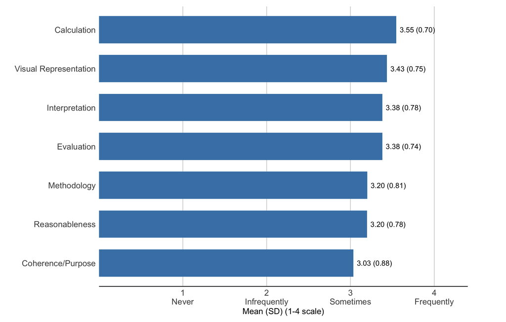

Note: Alternative of the above table.

## 2.2 Quantitative Reasoning Improvement and Confidence: Summary

### 2.2.1 Table 3. Frequencies of Quantitative Reasoning Improvement and Confidence

| QR Improvement and Confidence - Items | N = 4691 |
| --- | --- |
| [Improved General QR] How much has this course improved your general quantitative/numerical skills? |  |
| None | 32 (6.8%) |
| Minor improvement | 42 (9.0%) |
| Moderate improvement | 266 (57%) |
| Major improvement | 128 (27%) |
| [Improved Applied QR] How much has this course improved your ability to apply QR to real-world problems? |  |
| None | 16 (3.4%) |
| Minor improvement | 92 (20%) |
| Moderate improvement | 208 (44%) |
| Major improvement | 153 (33%) |
| [Confidence] How confident do you feel using numbers in your everyday life? |  |
| Not at all confident | 12 (2.6%) |
| Not confident | 27 (5.8%) |
| Confident | 280 (60%) |
| Very confident | 147 (32%) |

1n (%)

**Table 3** presents the frequencies of student responses regarding course improvement and confidence in quantitative reasoning.

For general quantitative/numerical skills improvement, most students (57%) report moderate improvement, with 27% reporting major improvement. Only 6.8% of students indicate no improvement in their quantitative skills from the course.

Regarding confidence in using numbers in everyday life, the majority of students feel confident (60%) or very confident (32%). Only 2.6% of students report feeling not at all confident, with 5.8% feeling not confident in using numbers day-to-day.

### 2.2.2 Figure 3. Frequencies of Quantitative Reasoning Improvement and Confidence

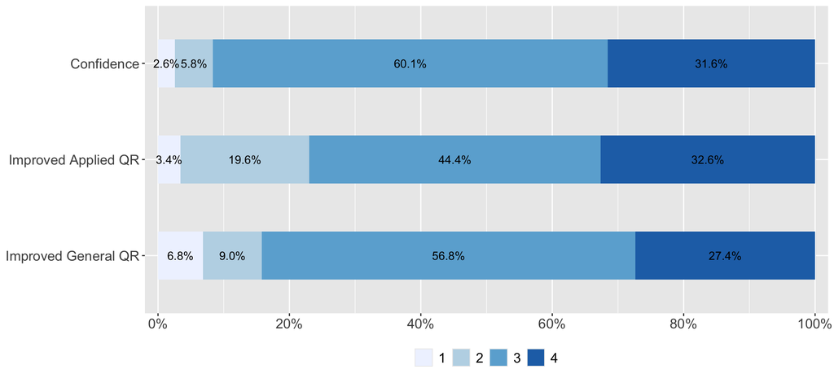

Note: Alternative of the above table.

### 2.2.3 Table 4. Descriptive Statistics of Quantitative Reasoning Improvement and Confidence

| QR Improvement and Confidence - Items | N = 4691 |
| --- | --- |
| [Confidence] How confident do you feel using numbers in your everyday life? | 3.21 (0.66) |
| [Improved Applied QR] How much has this course improved your ability to apply QR to real-world problems? | 3.06 (0.81) |
| [Improved General QR] How much has this course improved your general quantitative/numerical skills? | 3.05 (0.80) |

1Mean (SD)

**Table 4** presents the descriptive statistics of student improvement and confidence measures. Students report high confidence in using numbers in everyday life (M = 3.21). This score is the highest among the three measures.

### 2.2.4 Figure 4. Descriptive Statistics of Quantitative Reasoning Improvement and Confidence

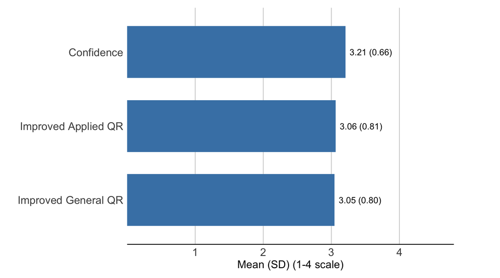

Note 1: Alternative of the above table.  
Note 2: Different response scales are used: QR Improvement (1-4: None to Major improvement) and Confidence (1-4: Not at all confident to Very confident).

## 2.3 Quantitative Reasoning Engagement: Summary

### 2.3.1 Table 5. Frequencies of Quantitative Reasoning Engagement

| Frequency of QR Engagement - Items | N = 4691 |
| --- | --- |
| [QR in World Issues] Used quantitative reasoning to examine a real-world problem or issue |  |
| Never | 39 (8.3%) |
| Infrequently | 78 (17%) |
| Sometimes | 178 (38%) |
| Frequently | 174 (37%) |
| [Frequency of Calculations] How frequently do you do calculations in your everyday life? |  |
| Never | 33 (7.1%) |
| Infrequently | 109 (23%) |
| Sometimes | 197 (42%) |
| Frequently | 127 (27%) |
| [Frequency of Graph Use] How frequently do you encounter graphs and tables in your everyday life? |  |
| Never | 78 (17%) |
| Infrequently | 179 (38%) |
| Sometimes | 141 (30%) |
| Frequently | 70 (15%) |
| [Frequency of Encounters] How frequently in your daily life do you encounter situations like those you have learned about in this course? |  |
| Never | 80 (17%) |
| Infrequently | 180 (38%) |
| Sometimes | 158 (34%) |
| Frequently | 51 (11%) |

1n (%)

**Table 5** presents the frequencies of student engagement with quantitative reasoning in various contexts.

For using quantitative reasoning to examine world issues, 37% of students do this frequently. For calculations in everyday life, 27% of students perform these frequently. Graph and table usage shows 15% of students encounter these frequently. Regarding course-related situations in daily life, 11% of students encounter these frequently.

These results show that quantitative reasoning skills are most frequently applied when examining world issues, followed by performing everyday calculations.

### 2.3.2 Figure 5. Frequencies of Quantitative Reasoning Engagement

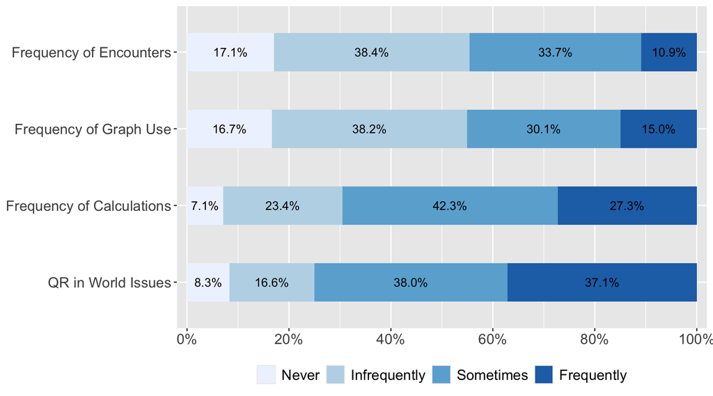

Note: Alternative of the above table.

### 2.3.3 Table 6. Descriptive Statistics of Quantitative Reasoning Engagement

| Frequency of QR Engagement - Items | N = 4691 |
| --- | --- |
| [QR in World Issues] Used quantitative reasoning to examine a real-world problem or issue | 3.04 (0.93) |
| [Frequency of Calculations] How frequently do you do calculations in your everyday life? | 2.90 (0.88) |
| [Frequency of Graph Use] How frequently do you encounter graphs and tables in your everyday life? | 2.43 (0.94) |
| [Frequency of Encounters] How frequently in your daily life do you encounter situations like those you have learned about in this course? | 2.38 (0.89) |

1Mean (SD)

**Table 6** presents the descriptive statistics of quantitative reasoning engagement measures.

Students most frequently use quantitative reasoning to examine world issues (M = 3.04). Frequency of calculations in everyday life shows a mean of 2.90. Graph and table usage displays a mean of 2.43.

Frequency of encountering course-related situations in daily life has the lowest mean at 2.38. Students experience situations similar to those taught in the course less frequently than other forms of quantitative engagement.

### 2.3.4 Figure 6. Descriptive Statistics of Quantitative Reasoning Engagement

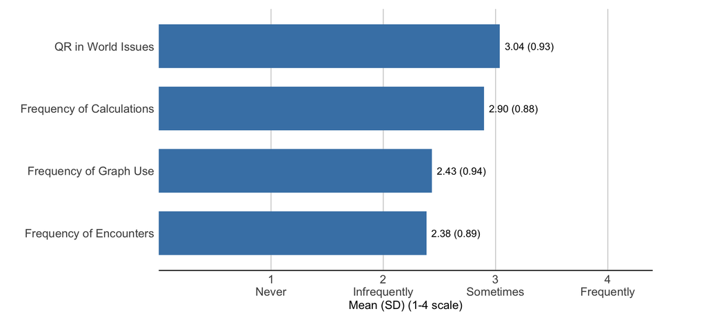

Note: Alternative of the above table.

## 2.4 Consolidated Results: Summary

### 2.4.1 Table 7. Consolidated Frequency Analysis of All Items

| All Items | N = 4691 |
| --- | --- |
| [Methodology] Described the methods used to solve a quantitative problem and why they were appropriate |  |
| Never | 19 (4.1%) |
| Infrequently | 57 (12%) |
| Sometimes | 202 (43%) |
| Frequently | 188 (40%) |
| [Calculation] Carried out calculations, either by hand or using software |  |
| Never | 9 (1.9%) |
| Infrequently | 30 (6.4%) |
| Sometimes | 125 (27%) |
| Frequently | 304 (65%) |
| [Visual Representation] Created a visual representation of numerical information (graph, table, chart, etc.) |  |
| Never | 14 (3.0%) |
| Infrequently | 33 (7.0%) |
| Sometimes | 157 (33%) |
| Frequently | 265 (57%) |
| [Interpretation] Described numerical information (numbers, graphs, statistics, etc.) by writing in words |  |
| Never | 12 (2.6%) |
| Infrequently | 51 (11%) |
| Sometimes | 151 (32%) |
| Frequently | 252 (54%) |
| [Evaluation] Reached conclusions based on your own analysis of numerical information (numbers, graphs, statistics, etc.) |  |
| Never | 10 (2.1%) |
| Infrequently | 42 (9.0%) |
| Sometimes | 175 (38%) |
| Frequently | 239 (51%) |
| [Coherence/Purpose] Constructed a single, coherent argument using several conclusions that were each based on quantitative evidence |  |
| Never | 27 (5.8%) |
| Infrequently | 89 (19%) |
| Sometimes | 190 (41%) |
| Frequently | 159 (34%) |
| [Reasonableness] Decided when a solution or inference was reasonable or not reasonable in the context of a problem |  |
| Never | 17 (3.6%) |
| Infrequently | 53 (11%) |
| Sometimes | 219 (47%) |
| Frequently | 179 (38%) |
| [Improved General QR] How much has this course improved your general quantitative/numerical skills? |  |
| None | 32 (6.8%) |
| Minor improvement | 42 (9.0%) |
| Moderate improvement | 266 (57%) |
| Major improvement | 128 (27%) |
| [Improved Applied QR] How much has this course improved your ability to apply QR to real-world problems? |  |
| None | 16 (3.4%) |
| Minor improvement | 92 (20%) |
| Moderate improvement | 208 (44%) |
| Major improvement | 153 (33%) |
| [Confidence] How confident do you feel using numbers in your everyday life? |  |
| Not at all confident | 12 (2.6%) |
| Not confident | 27 (5.8%) |
| Confident | 280 (60%) |
| Very confident | 147 (32%) |
| [QR in World Issues] Used quantitative reasoning to examine a real-world problem or issue |  |
| Never | 39 (8.3%) |
| Infrequently | 78 (17%) |
| Sometimes | 178 (38%) |
| Frequently | 174 (37%) |
| [Frequency of Calculations] How frequently do you do calculations in your everyday life? |  |
| Never | 33 (7.1%) |
| Infrequently | 109 (23%) |
| Sometimes | 197 (42%) |
| Frequently | 127 (27%) |
| [Frequency of Graph Use] How frequently do you encounter graphs and tables in your everyday life? |  |
| Never | 78 (17%) |
| Infrequently | 179 (38%) |
| Sometimes | 141 (30%) |
| Frequently | 70 (15%) |
| [Frequency of Encounters] How frequently in your daily life do you encounter situations like those you have learned about in this course? |  |
| Never | 80 (17%) |
| Infrequently | 180 (38%) |
| Sometimes | 158 (34%) |
| Frequently | 51 (11%) |

1n (%)

Note: Alternative of the above frequency tables.

### 2.4.2 Figure 7. Consolidated Frequency Analysis of All Items

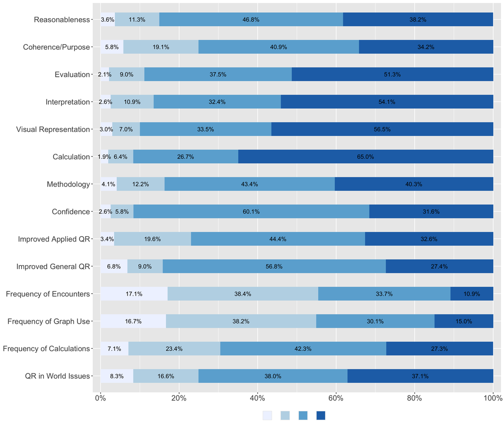

Note 1: Alternative of the above frequency graphs.  
Note 2: Different response scales are used: QR Core Skills & QR Engagement (1-4: Never to Frequently), QR Improvement (1-4: None to Major improvement), and Confidence (1-4: Not at all confident to Very confident).

### 2.4.3 Table 8. Consolidated Descriptive Statistics of All Items

| All Items | N = 4691 |
| --- | --- |
| [Calculation] Carried out calculations, either by hand or using software | 3.55 (0.70) |
| [Visual Representation] Created a visual representation of numerical information (graph, table, chart, etc.) | 3.43 (0.75) |
| [Interpretation] Described numerical information (numbers, graphs, statistics, etc.) by writing in words | 3.38 (0.78) |
| [Evaluation] Reached conclusions based on your own analysis of numerical information (numbers, graphs, statistics, etc.) | 3.38 (0.74) |
| [Confidence] How confident do you feel using numbers in your everyday life? | 3.21 (0.66) |
| [Methodology] Described the methods used to solve a quantitative problem and why they were appropriate | 3.20 (0.81) |
| [Reasonableness] Decided when a solution or inference was reasonable or not reasonable in the context of a problem | 3.20 (0.78) |
| [Improved Applied QR] How much has this course improved your ability to apply QR to real-world problems? | 3.06 (0.81) |
| [Improved General QR] How much has this course improved your general quantitative/numerical skills? | 3.05 (0.80) |
| [QR in World Issues] Used quantitative reasoning to examine a real-world problem or issue | 3.04 (0.93) |
| [Coherence/Purpose] Constructed a single, coherent argument using several conclusions that were each based on quantitative evidence | 3.03 (0.88) |
| [Frequency of Calculations] How frequently do you do calculations in your everyday life? | 2.90 (0.88) |
| [Frequency of Graph Use] How frequently do you encounter graphs and tables in your everyday life? | 2.43 (0.94) |
| [Frequency of Encounters] How frequently in your daily life do you encounter situations like those you have learned about in this course? | 2.38 (0.89) |

1Mean (SD)

Note: Alternative of the above descriptive statistics tables.

### 2.4.4 Figure 8. Consolidated Descriptive Statistics of All Items

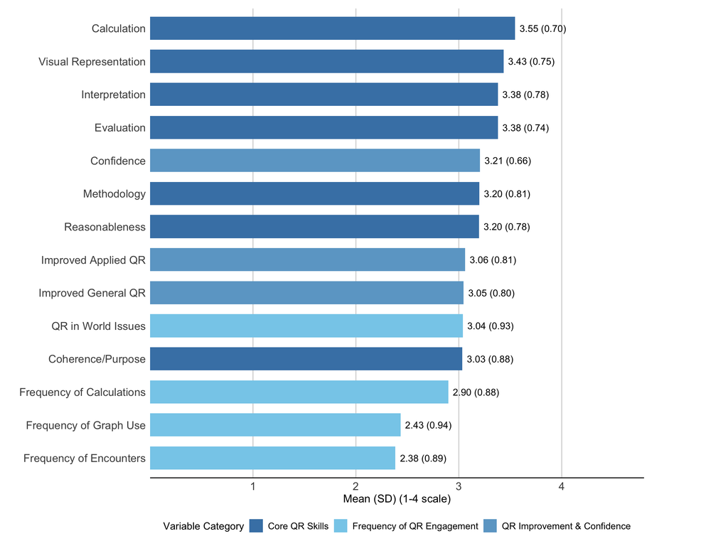

Note 1: Alternative of the above descriptive statistics graphs.  
Note 2: Different response scales are used: Core QR Skills & QR Engagement (1-4: Never to Frequently), QR Improvement (1-4: None to Major improvement), and Confidence (1-4: Not at all confident to Very confident).

# 3 Correlation Analyses

## 3.1 Figure 9. Correlation Matrix of All Variables

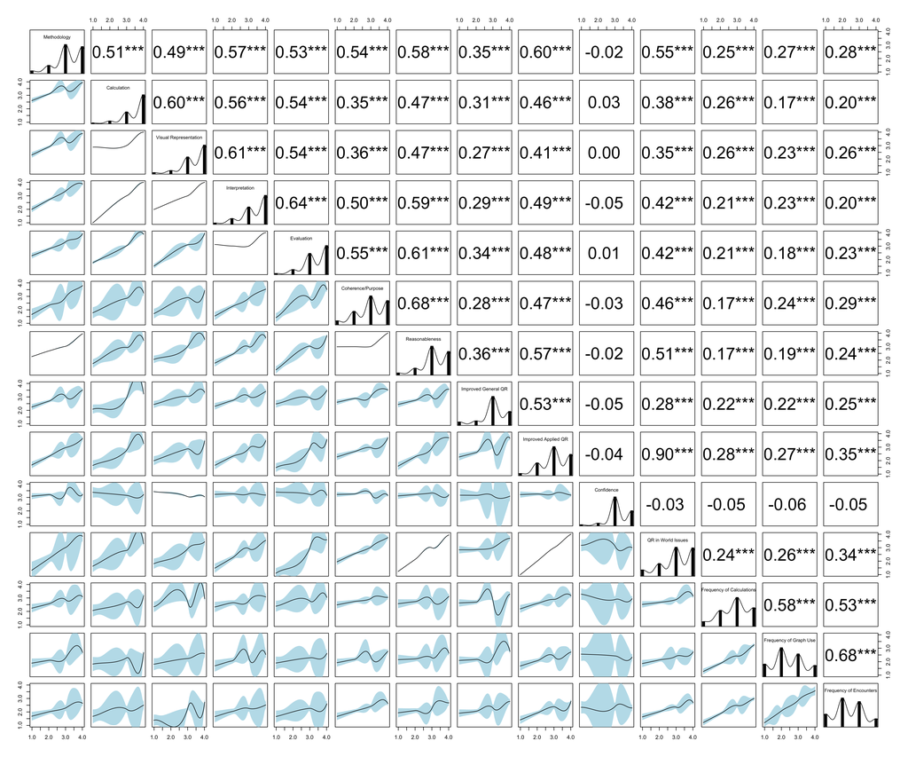

Note: Bottom-left cells show scatterplots; diagonal cells show variable distributions. Top-right values are Pearson *r* coefficients. Correlation strength: weak (|r| < 0.3), moderate (0.3 < |r| < 0.5), strong (|r| > 0.5). * p < .05, ** p < .01, *** p < .001. Plot may be simplified, or variables/smoothers removed, due to limited sample size.

**Figure 9** presents the correlation matrix of all variables.

The strongest correlations within the core quantitative reasoning skills are observed between:

- Coherence/Purpose and Reasonableness (*r* = 0.68, *p*<0.001)
- Evaluation and Interpretation (*r* = 0.64, *p*<0.001)
- Interpretation and Visual Representation (*r* = 0.61, *p*<0.001)

These strong correlations may suggest that students who build coherent arguments backed by quantitative evidence also tend to judge the reasonableness of solutions. Students with strong evaluation skills typically have strong interpretation abilities, and those who interpret numerical information also create visual representations of data.

Within the qualitative reasoning engagement variables, the analysis reveals a statistically significant correlation (*r* = 0.68, *p*<0.001) between students’ reported frequency of encountering graphs and tables in everyday life and their experience with course-related situations in daily contexts.

## 3.2 Figure 10. Correlogram of All Variables

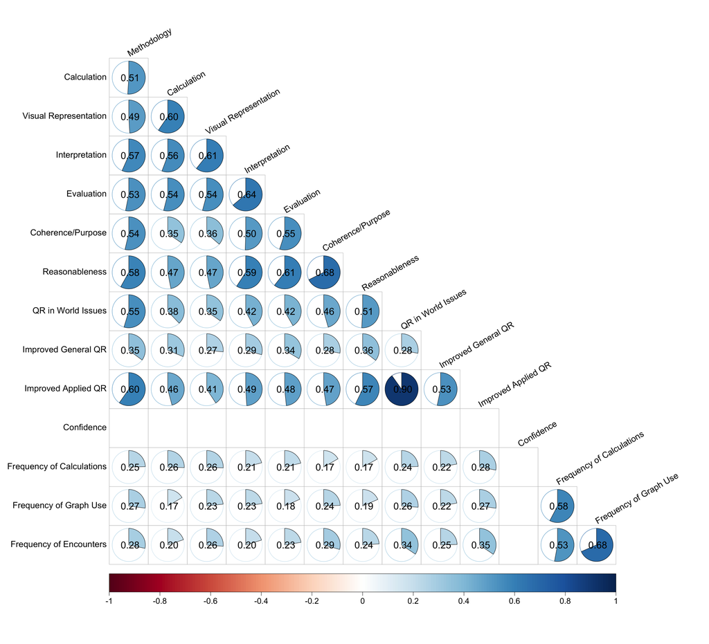

Note 1: Alternative of the above graph.  
Note 2: Cells represent the correlation coefficient between two variables. Blue shows positive correlations, red shows negative correlations, and circle size reflects correlation magnitude. Correlation strength: weak (|r| < 0.3), moderate (0.3 < |r| < 0.5), strong (|r| > 0.5). Insignificant correlations are invisible (p > .05).

# 4 Regression Analyses

## 4.1 Table 9. Linear Regression Model Predicting Coherence/Purpose

| Linear Regression Model Predicting Coherence/Purpose Predictor | Linear Regression Model Predicting Coherence/Purpose Estimate | Linear Regression Model Predicting Coherence/Purpose SE | Linear Regression Model Predicting Coherence/Purpose 95% CI | Linear Regression Model Predicting Coherence/Purpose p-value |
| --- | --- | --- | --- | --- |
| Intercept | -0.01 | (0.03) | [-0.06, 0.05] | 0.837 |
| Methodology | 0.21*** | (0.05) | [0.11, 0.30] | 0.000 |
| Calculation | -0.11† | (0.06) | [-0.22, 0.00] | 0.053 |
| Visual Representation | -0.05 | (0.05) | [-0.16, 0.05] | 0.310 |
| Interpretation | 0.07 | (0.06) | [-0.04, 0.18] | 0.209 |
| Evaluation | 0.24*** | (0.06) | [0.13, 0.35] | 0.000 |
| Reasonableness | 0.53*** | (0.05) | [0.43, 0.63] | 0.000 |

SE = Standard Error, CI = Confidence Interval † p < .10, * p < .05, ** p < .01, *** p < .001 R² = 0.511; Adjusted R² = 0.505

A linear regression was conducted to identify the factors that influence students’ ability to construct a single, coherent argument using several conclusions based on quantitative evidence—referred to as “Coherence/Purpose.” This item received the lowest “frequently” responses at 34.2%, as noted in prior sections. Note that all variables were mean-centered prior to analyses to minimize multicollinearity.

The results reveal that four skills significantly influence the ability to construct coherent quantitative arguments. Specifically, the skill of describing the methods used to solve a quantitative problem and justifying their appropriateness increases the “Coherence/Purpose” score by 0.21 points on a 1-to-4 scale. Similarly, the ability to reach conclusions based on one’s own analysis of numerical information, such as numbers, graphs, or statistics, increases the score by 0.24 points. The most substantial impact arises from deciding when a solution or inference is reasonable within a problem’s context, which increases the Coherence/Purpose score by 0.53 points. Finally, “Carried out calculations, either by hand or using software” shows a negative effect, decreasing the Coherence/Purpose score by 0.11 points. This effect is significant at a marginal level (*p* < 0.10), a less reliable but noteworthy influence that warrants further exploration. The model explains approximately 51.1% of the variance in “Coherence/Purpose” (R² = 0.511).

| Linear Regression Model Predicting QR Improvement Predictor | Linear Regression Model Predicting QR Improvement Estimate | Linear Regression Model Predicting QR Improvement SE | Linear Regression Model Predicting QR Improvement 95% CI | Linear Regression Model Predicting QR Improvement p-value |
| --- | --- | --- | --- | --- |
| Intercept | 0.01 | (0.03) | [-0.04, 0.06] | 0.717 |
| QR Core Skills | 0.55*** | (0.05) | [0.46, 0.65] | 0.000 |
| Confidence | -0.03 | (0.04) | [-0.10, 0.05] | 0.467 |
| QR Engagement | 0.29*** | (0.04) | [0.21, 0.37] | 0.000 |

SE = Standard Error, CI = Confidence Interval † p < .10, * p < .05, ** p < .01, *** p < .001 R² = 0.430; Adjusted R² = 0.426

A linear regression was conducted to identify the factors that influence students’ self-reported improvement. For this analysis, composite indexes were used.